# markdown_test

2024-01-08

## Cross-sectional anti-immigration modelling

Dependent variable and model:

- Opposition to immigration measured on an 11-point scale from 0 (should allow many more immigrants) to 10 (should allow far fewer immigrants)
- Nested multilevel linear model with random intercepts for local authorities, with cross-level interactions between housing affordability and a) social renting and b) homeownership
- Affordability measured via the ratio of median house prices to median earnings in a local authority; as such, a higher number indicates less affordable housing

Key findings:

- The association between affordability and opposition to immigration is conditional on tenure
- A positive interaction exists between social renting and unaffordability
- A negative interaction exists between homeownership and unaffordability
- Findings robust to log transformation of affordability, using log of house prices as independent variable, and inclusion of regional dummies

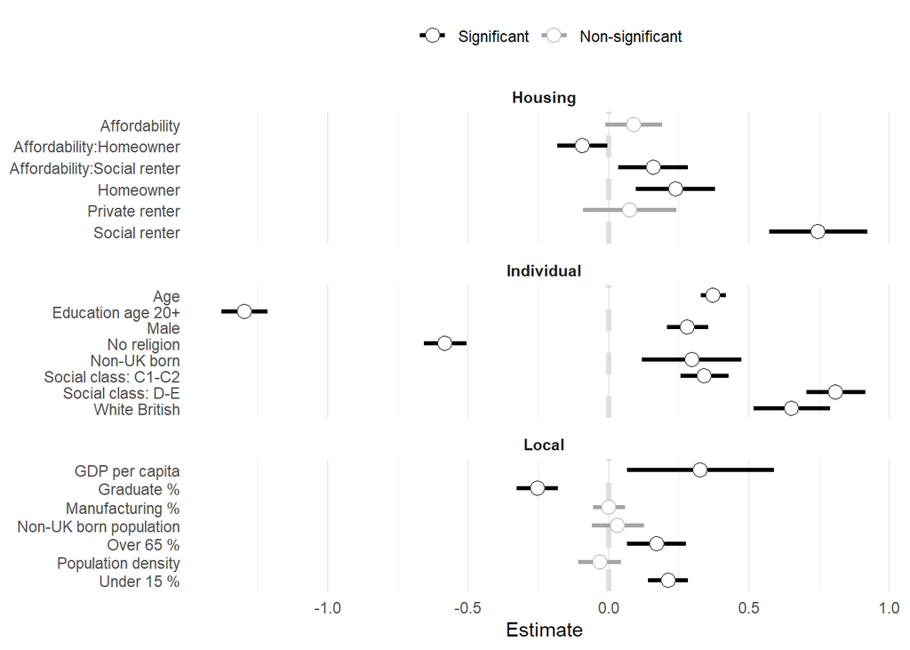

The figure below displays the interaction terms. It also shows that once controlling for the confounding influence of the percentage of people with degrees in a local authority, for many tenures there is a positive association between high house prices and right wing political attitudes.

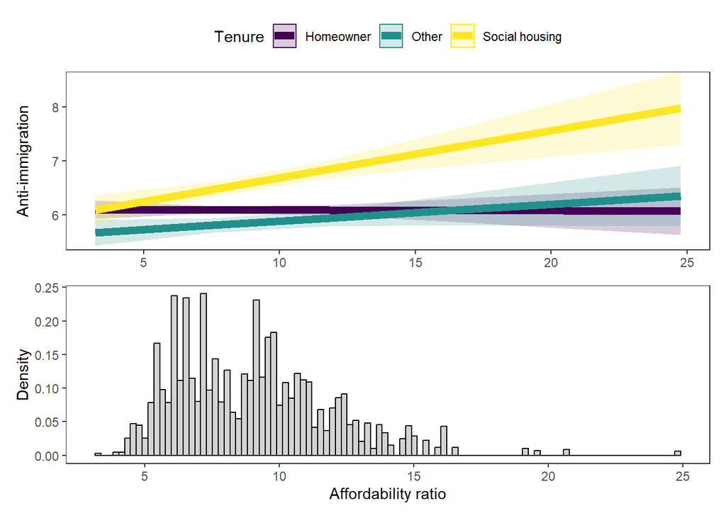

## Cross-sectional immigrants a burden on welfare modelling

Dependent variable and model:

- Binary indicator for whether respondents ‘agree’ or ‘strongly agree’ that immigrants are a burden on the welfare state
- Nested multilevel logit model with random intercepts for local authorities, with cross-level interactions between housing affordability and a) social renting and b) homeownership

Key findings:

- Positive association with social renting and homeownership
- Positive interaction between social renting and affordability i.e. social renters in less affordable areas more likely to see immigrants as a welfare state burden
- Interaction between social renting and affordability robust to using log of affordability, log of house prices, and inclusion of regional dummies
- No interaction with homeownership

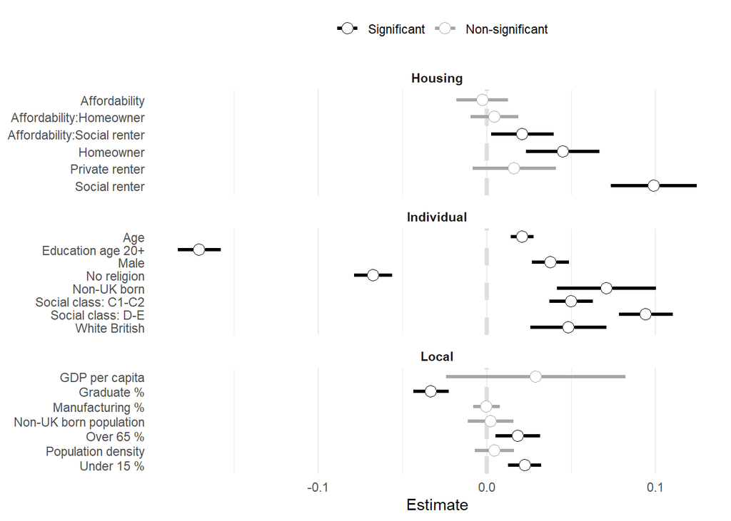

## Cross-sectional racial equality modelling

Dependent variable and model:

- Opposition to racial equality measured as a binary indicator (1 = racial equality has “gone too far” or “gone much too far”)
- Nested multilevel logit model with random intercepts for local authorities, with cross-level interactions between housing affordability and a) social renting and b) homeownership

Key findings:

- No effect of housing affordability, or the interaction terms
- Homeowners more likely to think racial equality has gone too far than other tenures

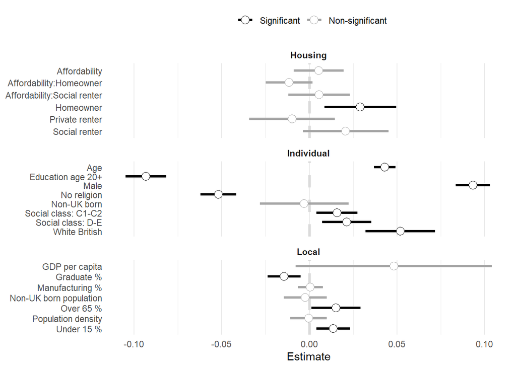

## Table of cross-sectional modelling results

Anti-immigration

Immigrants a welfare burden

Anti-racial equality

Predictors

Estimates

CI

Odds Ratios

CI

Odds Ratios

CI

Social renter

0.75 ***

0.57 – 0.92

1.64 ***

1.45 – 1.87

1.13

0.98 – 1.30

Homeowner

0.24 ***

0.10 – 0.38

1.25 ***

1.12 – 1.40

1.18 **

1.05 – 1.33

Private renter

0.08

-0.09 – 0.24

1.08

0.96 – 1.23

0.94

0.82 – 1.09

Affordability

0.09

-0.01 – 0.19

0.99

0.91 – 1.07

1.03

0.95 – 1.12

Social renter * Affordability

0.16 *

0.04 – 0.28

1.11 *

1.01 – 1.22

1.03

0.93 – 1.14

Homeowner * Affordability

-0.09 *

-0.18 – -0.01

1.02

0.95 – 1.10

0.94

0.87 – 1.01

Random Effects

σ<sup>2</sup>

7.79

3.29

3.29

τ<sub>00</sub>

0.02 <sub>LAD</sub>

0.00 <sub>LAD</sub>

0.01 <sub>LAD</sub>

ICC

0.00

0.00

0.00

N

329 <sub>LAD</sub>

329 <sub>LAD</sub>

329 <sub>LAD</sub>

Observations

22669

25710

27596

Marginal R<sup>2</sup> / Conditional R<sup>2</sup>

0.157 / 0.159

0.125 / 0.125

0.102 / 0.103

AIC

111075.632

30049.977

29014.387

- p<0.05 ** p<0.01 *** p<0.001

## Longitudinal anti-immigration modelling

Data and modelling strategy:

- Six waves of the British Election Study (BES) ranging from 2016-2021, filtered to respondents who participated in at least three waves
- Random effect within-between (REWB) model with two-way cross-classified structure i.e. random intercept for respondent and random intercept for local authority
- Cross-level interaction between between authority affordability and tenure (i.e. social renting and homeonwership, respectively)

Key findings:

- Association of between affordability with opposition to immmigration is again contingent upon tenure, with the direction of the interactions consistent with the cross-sectional modelling, but only the interaction with social renting statistically significant
- Variation in affordability within local authorities not associated with the outcome variable; therefore, no evidence of geotropic effect
- Findings robust to: a) log scale of affordability as dependent variable, b) log house prices as dependent variable, and c) including as an independent variable the change between censuses in the percentage of people degree educated in a local authority

Anti-immigration (longitudinal)

Predictors

Estimates

CI

Social renter

0.55 ***

0.46 – 0.64

Homeowner

0.22 ***

0.15 – 0.29

Private renter

-0.02

-0.09 – 0.06

Affordability between

0.06

-0.00 – 0.13

Social renter * Affordability between

0.10 **

0.04 – 0.17

Homeowner * Affordability between

-0.05

-0.09 – 0.00

Affordability within

0.00

-0.01 – 0.01

Random Effects

σ<sup>2</sup>

1.68

τ<sub>00</sub> <sub>id</sub>

5.05

τ<sub>00</sub> <sub>LAD</sub>

0.02

ICC

0.75

N <sub>LAD</sub>

329

N <sub>id</sub>

26885

Observations

98090

Marginal R<sup>2</sup> / Conditional R<sup>2</sup>

0.068 / 0.768

AIC

394918.373

- p<0.05 ** p<0.01 *** p<0.001